# 911 Calls Project

## Tyler Chia

For this project we will be analyzing some 911 call data from [Kaggle](https://www.kaggle.com/mchirico/montcoalert). All the data is specific to Montgomery County, Pennsylvania.

## Question 1: Data and Setup

```python
# Import Pandas and Numpy
```

```python
import pandas as pd
import numpy as np
```

```python
# Import visualization libraries and set %matplotlib inline.
```

```python
%matplotlib inline
```

```python
# Read in csv file
```

```python
df = pd.read_csv('911.csv')
```

```python
# Check the info of the dataframe
```

```python
df.info()
```

```
<class 'pandas.core.frame.DataFrame'>
RangeIndex: 99492 entries, 0 to 99491
Data columns (total 9 columns):
 #   Column     Non-Null Count  Dtype
---  ------     --------------  -----
 0   lat        99492 non-null  float64
 1   lng        99492 non-null  float64
 2   desc       99492 non-null  object
 3   zip        86637 non-null  float64
 4   title      99492 non-null  object
 5   timeStamp  99492 non-null  object
 6   twp        99449 non-null  object
 7   addr       98973 non-null  object
 8   e          99492 non-null  int64
dtypes: float64(3), int64(1), object(5)
memory usage: 6.8+ MB
```

```python
# Check the head of the dataframe
```

```python
df.head()
```

|  | lat | lng | desc | zip | title | timeStamp | twp | addr | e |
| --- | --- | --- | --- | --- | --- | --- | --- | --- | --- |
| 0 | 40.297876 | -75.581294 | REINDEER CT & DEAD END; NEW HANOVER; Station ... | 19525.0 | EMS: BACK PAINS/INJURY | 2015-12-10 17:40:00 | NEW HANOVER | REINDEER CT & DEAD END | 1 |
| 1 | 40.258061 | -75.264680 | BRIAR PATH & WHITEMARSH LN; HATFIELD TOWNSHIP... | 19446.0 | EMS: DIABETIC EMERGENCY | 2015-12-10 17:40:00 | HATFIELD TOWNSHIP | BRIAR PATH & WHITEMARSH LN | 1 |
| 2 | 40.121182 | -75.351975 | HAWS AVE; NORRISTOWN; 2015-12-10 @ 14:39:21-St... | 19401.0 | Fire: GAS-ODOR/LEAK | 2015-12-10 17:40:00 | NORRISTOWN | HAWS AVE | 1 |
| 3 | 40.116153 | -75.343513 | AIRY ST & SWEDE ST; NORRISTOWN; Station 308A;... | 19401.0 | EMS: CARDIAC EMERGENCY | 2015-12-10 17:40:01 | NORRISTOWN | AIRY ST & SWEDE ST | 1 |
| 4 | 40.251492 | -75.603350 | CHERRYWOOD CT & DEAD END; LOWER POTTSGROVE; S... | NaN | EMS: DIZZINESS | 2015-12-10 17:40:01 | LOWER POTTSGROVE | CHERRYWOOD CT & DEAD END | 1 |

## Question 2: Basic Information From the Dataframe

```python
# What are the top 5 zipcodes for 911 calls?
```

```python
df['zip'].value_counts().head()
```

```
19401.0    6979
19464.0    6643
19403.0    4854
19446.0    4748
19406.0    3174
Name: zip, dtype: int64
```

The top five zipcodes for 911 calls are 19401, 19464, 19403, 19446, and 19406 with the total number of calls to the right of the zipcode number.

```python
# What are the top 5 townships for 911 calls?
```

```python
df['twp'].value_counts().head()
```

```
LOWER MERION    8443
ABINGTON        5977
NORRISTOWN      5890
UPPER MERION    5227
CHELTENHAM      4575
Name: twp, dtype: int64
```

The top five townships for 911 calls are Lower Merion, Abington, Norristown, Upper Merrion, and Cheltenham with the number of 911 calls to the right of the township name.

```python
# How many unique title codes are there?
```

```python
df['title'].nunique()
```

```
110
```

There are 110 unique title codes in the dataframe for 911 calls.

## Question 3: Creating New Features

```python
# Adding a new column to the dataframe that shows the reason for the 911 call
```

```python
# Creating a function that splits the title column and takes the string before the colon
# in order to extract the reason for the call
```

```python
def reason(title):
    return title.split(':')[0]
```

```python
df['Reason'] = df['title'].apply(lambda x: reason(x))
```

```python
df['Reason']
```

```
0            EMS
1            EMS
2           Fire
3            EMS
4            EMS
          ...
99487    Traffic
99488    Traffic
99489        EMS
99490        EMS
99491    Traffic
Name: Reason, Length: 99492, dtype: object
```

```python
# What is the most common Reason for a 911 call based off of this new column?
```

```python
df['Reason'].value_counts()
```

```
EMS        48877
Traffic    35695
Fire       14920
Name: Reason, dtype: int64
```

The most common reason for a 911 call in Montgomery County, Pennsylvania is EMS.

## Question 4: Visualization of the Data

```python
# Import both seaborn and matplotlib for data visualization
```

```python
import seaborn as sns
```

```python
import matplotlib.pyplot as plt
```

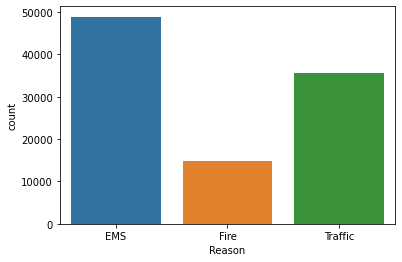

```python
sns.countplot(x = 'Reason', data=df)
```

Above is a countplot that shows the total number of calls based on each of the three reasons: EMS, Fire, and Traffic.

```python
# Convert timeStamp variable from a string to DateTime objects
```

```python
type(df['timeStamp'].iloc[0])
```

```
str
```

The data type of the objects in the timeStamp column are strings.

```python
df['timeStamp'] = pd.to_datetime(df['timeStamp'])
```

```python
# Create three new colummns that display the hour, month, and day respectively
```

```python
df['Hour'] = df['timeStamp'].apply(lambda x: x.hour)
df['Month'] = df['timeStamp'].apply(lambda x: x.month)
df['Day'] = df['timeStamp'].apply(lambda x: x.dayofweek)
df.head()
```

|  | lat | lng | desc | zip | title | timeStamp | twp | addr | e | Reason | Hour | Month | Day |
| --- | --- | --- | --- | --- | --- | --- | --- | --- | --- | --- | --- | --- | --- |
| 0 | 40.297876 | -75.581294 | REINDEER CT & DEAD END; NEW HANOVER; Station ... | 19525.0 | EMS: BACK PAINS/INJURY | 2015-12-10 17:40:00 | NEW HANOVER | REINDEER CT & DEAD END | 1 | EMS | 17 | 12 | 3 |
| 1 | 40.258061 | -75.264680 | BRIAR PATH & WHITEMARSH LN; HATFIELD TOWNSHIP... | 19446.0 | EMS: DIABETIC EMERGENCY | 2015-12-10 17:40:00 | HATFIELD TOWNSHIP | BRIAR PATH & WHITEMARSH LN | 1 | EMS | 17 | 12 | 3 |
| 2 | 40.121182 | -75.351975 | HAWS AVE; NORRISTOWN; 2015-12-10 @ 14:39:21-St... | 19401.0 | Fire: GAS-ODOR/LEAK | 2015-12-10 17:40:00 | NORRISTOWN | HAWS AVE | 1 | Fire | 17 | 12 | 3 |
| 3 | 40.116153 | -75.343513 | AIRY ST & SWEDE ST; NORRISTOWN; Station 308A;... | 19401.0 | EMS: CARDIAC EMERGENCY | 2015-12-10 17:40:01 | NORRISTOWN | AIRY ST & SWEDE ST | 1 | EMS | 17 | 12 | 3 |
| 4 | 40.251492 | -75.603350 | CHERRYWOOD CT & DEAD END; LOWER POTTSGROVE; S... | NaN | EMS: DIZZINESS | 2015-12-10 17:40:01 | LOWER POTTSGROVE | CHERRYWOOD CT & DEAD END | 1 | EMS | 17 | 12 | 3 |

The Day column displays the day as an integer from 0 to 6. I then created a dictionary to map each of the integers to a string name for each day of the week.

```python
dmap = {0:'Mon',1:'Tue',2:'Wed',3:'Thu',4:'Fri',5:'Sat',6:'Sun'}
```

```python
df['Day'] = df['Day'].apply(lambda x: dmap[x])

df.head()
```

|  | lat | lng | desc | zip | title | timeStamp | twp | addr | e | Reason | Hour | Month | Day |
| --- | --- | --- | --- | --- | --- | --- | --- | --- | --- | --- | --- | --- | --- |
| 0 | 40.297876 | -75.581294 | REINDEER CT & DEAD END; NEW HANOVER; Station ... | 19525.0 | EMS: BACK PAINS/INJURY | 2015-12-10 17:40:00 | NEW HANOVER | REINDEER CT & DEAD END | 1 | EMS | 17 | 12 | Thu |
| 1 | 40.258061 | -75.264680 | BRIAR PATH & WHITEMARSH LN; HATFIELD TOWNSHIP... | 19446.0 | EMS: DIABETIC EMERGENCY | 2015-12-10 17:40:00 | HATFIELD TOWNSHIP | BRIAR PATH & WHITEMARSH LN | 1 | EMS | 17 | 12 | Thu |
| 2 | 40.121182 | -75.351975 | HAWS AVE; NORRISTOWN; 2015-12-10 @ 14:39:21-St... | 19401.0 | Fire: GAS-ODOR/LEAK | 2015-12-10 17:40:00 | NORRISTOWN | HAWS AVE | 1 | Fire | 17 | 12 | Thu |
| 3 | 40.116153 | -75.343513 | AIRY ST & SWEDE ST; NORRISTOWN; Station 308A;... | 19401.0 | EMS: CARDIAC EMERGENCY | 2015-12-10 17:40:01 | NORRISTOWN | AIRY ST & SWEDE ST | 1 | EMS | 17 | 12 | Thu |
| 4 | 40.251492 | -75.603350 | CHERRYWOOD CT & DEAD END; LOWER POTTSGROVE; S... | NaN | EMS: DIZZINESS | 2015-12-10 17:40:01 | LOWER POTTSGROVE | CHERRYWOOD CT & DEAD END | 1 | EMS | 17 | 12 | Thu |

```python
# Creating a countplot that counts the number of calls per day of the week
# and splits them based on the reason for the call
```

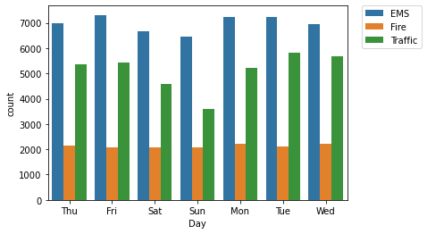

```python
sns.countplot(x = 'Day', data = df, hue = 'Reason')
plt.legend(bbox_to_anchor=(1.05, 1), loc=2, borderaxespad=0.)
```

```python
# Creating the same countplot for months
```

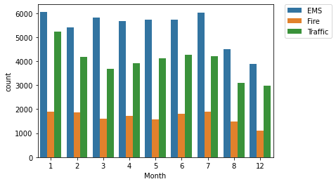

```python
sns.countplot(x = 'Month', data = df, hue = 'Reason')
plt.legend(bbox_to_anchor=(1.05, 1), loc=2, borderaxespad=0.)
```

We can see that the number of 911 calls in Montgomery County, Pennsylvania start to drop later in the year as the lowest number of calls was made in December.

Looking at the plot above, it is clear that certain months are missing from the dataset. September, October, and November are all not included in the dataset.

```python
# Create a groupby object that groups the data by month and aggregate the data
```

```python
byMonth = df.groupby('Month').count()
byMonth.head()
```

| Month | lat | lng | desc | zip | title | timeStamp | twp | addr | e | Reason | Hour | Day |
| --- | --- | --- | --- | --- | --- | --- | --- | --- | --- | --- | --- | --- |
| 1 | 13205 | 13205 | 13205 | 11527 | 13205 | 13205 | 13203 | 13096 | 13205 | 13205 | 13205 | 13205 |
| 2 | 11467 | 11467 | 11467 | 9930 | 11467 | 11467 | 11465 | 11396 | 11467 | 11467 | 11467 | 11467 |
| 3 | 11101 | 11101 | 11101 | 9755 | 11101 | 11101 | 11092 | 11059 | 11101 | 11101 | 11101 | 11101 |
| 4 | 11326 | 11326 | 11326 | 9895 | 11326 | 11326 | 11323 | 11283 | 11326 | 11326 | 11326 | 11326 |
| 5 | 11423 | 11423 | 11423 | 9946 | 11423 | 11423 | 11420 | 11378 | 11423 | 11423 | 11423 | 11423 |

```python
# Create a simple lineplot that shows the number of calls based on the month
```

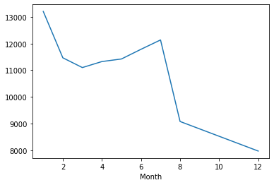

```python
byMonth['desc'].plot()
```

```python
# Create a lmplot() to create a linear fit on the number of calls per month
```

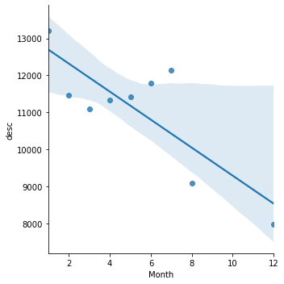

```python
byMonth = byMonth.reset_index()
sns.lmplot(x = 'Month', y = 'desc', data = byMonth)
```

Even though September, October, and November are missing from the dataset, we can use an lmplot to predict these numbers based on the months preceding this patch as well as the months following it.

```python
# Create a new column that shows the date
```

```python
df['Date'] = df['timeStamp'].apply(lambda x: x.date())
df.head()
```

|  | lat | lng | desc | zip | title | timeStamp | twp | addr | e | Reason | Hour | Month | Day | Date |
| --- | --- | --- | --- | --- | --- | --- | --- | --- | --- | --- | --- | --- | --- | --- |
| 0 | 40.297876 | -75.581294 | REINDEER CT & DEAD END; NEW HANOVER; Station ... | 19525.0 | EMS: BACK PAINS/INJURY | 2015-12-10 17:40:00 | NEW HANOVER | REINDEER CT & DEAD END | 1 | EMS | 17 | 12 | Thu | 2015-12-10 |
| 1 | 40.258061 | -75.264680 | BRIAR PATH & WHITEMARSH LN; HATFIELD TOWNSHIP... | 19446.0 | EMS: DIABETIC EMERGENCY | 2015-12-10 17:40:00 | HATFIELD TOWNSHIP | BRIAR PATH & WHITEMARSH LN | 1 | EMS | 17 | 12 | Thu | 2015-12-10 |
| 2 | 40.121182 | -75.351975 | HAWS AVE; NORRISTOWN; 2015-12-10 @ 14:39:21-St... | 19401.0 | Fire: GAS-ODOR/LEAK | 2015-12-10 17:40:00 | NORRISTOWN | HAWS AVE | 1 | Fire | 17 | 12 | Thu | 2015-12-10 |
| 3 | 40.116153 | -75.343513 | AIRY ST & SWEDE ST; NORRISTOWN; Station 308A;... | 19401.0 | EMS: CARDIAC EMERGENCY | 2015-12-10 17:40:01 | NORRISTOWN | AIRY ST & SWEDE ST | 1 | EMS | 17 | 12 | Thu | 2015-12-10 |
| 4 | 40.251492 | -75.603350 | CHERRYWOOD CT & DEAD END; LOWER POTTSGROVE; S... | NaN | EMS: DIZZINESS | 2015-12-10 17:40:01 | LOWER POTTSGROVE | CHERRYWOOD CT & DEAD END | 1 | EMS | 17 | 12 | Thu | 2015-12-10 |

```python
# Perform a groupby on the data that groups together by date
```

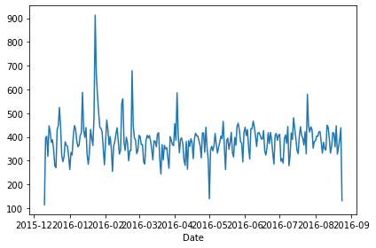

```python
byDate = df.groupby('Date').count()
byDate['desc'].plot()
plt.tight_layout()
```

```python
# Create a plot that shows the number of traffic related calls based on date
```

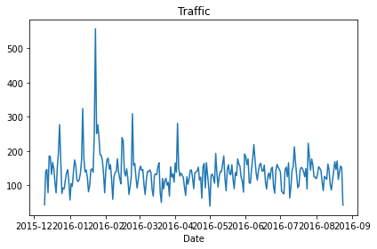

```python
byTraffic = df[df['Reason'] == 'Traffic']
byTraffic.groupby('Date').count()['desc'].plot()
plt.title('Traffic')
plt.tight_layout()
```

According to the graph, it seems that in the middle of January of 2016, there was a drastic increase in the number of 911 calls in Montgomery County, Pennsylvania.

```python
# Create a plot that shows the number of fire related calls based on date
```

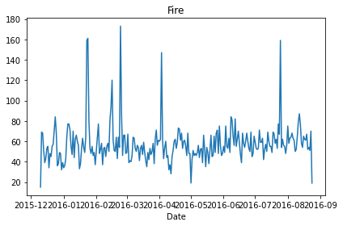

```python
byFire = df[df['Reason'] == 'Fire']
byFire.groupby('Date').count()['desc'].plot()
plt.title('Fire')
plt.tight_layout()
```

```python
# Create a plot that shows the number of EMS related calls based on date
```

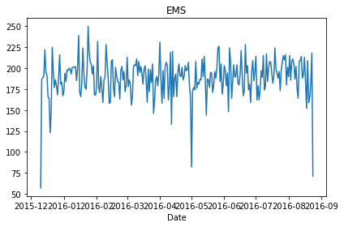

```python
byEMS = df[df['Reason'] == 'EMS']
byEMS.groupby('Date').count()['desc'].plot()
plt.title('EMS')
plt.tight_layout()
```

```python
# Restructure the dataframe so that the columns become the Hours and the Index becomes the Day of the Week.
```

```python
dayandhour = df.groupby(by=['Day','Hour']).count()['Reason'].unstack()
dayandhour.head()
```

| Hour Day | 0 | 1 | 2 | 3 | 4 | 5 | 6 | 7 | 8 | 9 | ... | 14 | 15 | 16 | 17 | 18 | 19 | 20 | 21 | 22 | 23 |
| --- | --- | --- | --- | --- | --- | --- | --- | --- | --- | --- | --- | --- | --- | --- | --- | --- | --- | --- | --- | --- | --- |
| Fri | 275 | 235 | 191 | 175 | 201 | 194 | 372 | 598 | 742 | 752 | ... | 932 | 980 | 1039 | 980 | 820 | 696 | 667 | 559 | 514 | 474 |
| Mon | 282 | 221 | 201 | 194 | 204 | 267 | 397 | 653 | 819 | 786 | ... | 869 | 913 | 989 | 997 | 885 | 746 | 613 | 497 | 472 | 325 |
| Sat | 375 | 301 | 263 | 260 | 224 | 231 | 257 | 391 | 459 | 640 | ... | 789 | 796 | 848 | 757 | 778 | 696 | 628 | 572 | 506 | 467 |
| Sun | 383 | 306 | 286 | 268 | 242 | 240 | 300 | 402 | 483 | 620 | ... | 684 | 691 | 663 | 714 | 670 | 655 | 537 | 461 | 415 | 330 |
| Thu | 278 | 202 | 233 | 159 | 182 | 203 | 362 | 570 | 777 | 828 | ... | 876 | 969 | 935 | 1013 | 810 | 698 | 617 | 553 | 424 | 354 |

5 rows × 24 columns

```python
# Create a heatmap using seaborn
```

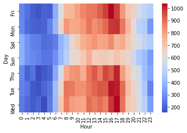

```python
sns.heatmap(dayandhour, cmap='coolwarm')
```

```python
# Create a clustermap based on the data
```

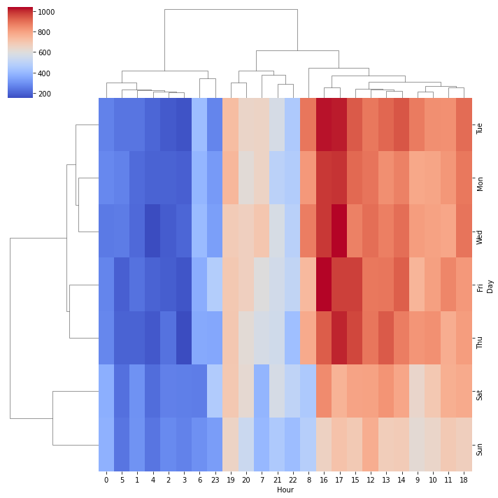

```python
sns.clustermap(dayandhour, cmap='coolwarm')
```

```python
# Create a heatmap using seaborn that is based on month as opposed to hour
```

```python
dayandmonth = df.groupby(by=['Day','Month']).count()['Reason'].unstack()
dayandmonth.head()
```

| Month Day | 1 | 2 | 3 | 4 | 5 | 6 | 7 | 8 | 12 |
| --- | --- | --- | --- | --- | --- | --- | --- | --- | --- |
| Fri | 1970 | 1581 | 1525 | 1958 | 1730 | 1649 | 2045 | 1310 | 1065 |
| Mon | 1727 | 1964 | 1535 | 1598 | 1779 | 1617 | 1692 | 1511 | 1257 |
| Sat | 2291 | 1441 | 1266 | 1734 | 1444 | 1388 | 1695 | 1099 | 978 |
| Sun | 1960 | 1229 | 1102 | 1488 | 1424 | 1333 | 1672 | 1021 | 907 |
| Thu | 1584 | 1596 | 1900 | 1601 | 1590 | 2065 | 1646 | 1230 | 1266 |

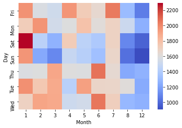

```python
sns.heatmap(dayandmonth, cmap='coolwarm')
```

From the heatmap above, there is a drastic increase in the number of 911 calls on Saturdays in January in Montgomery County, Pennsylvania.

```python
# Create a new clustermap
```

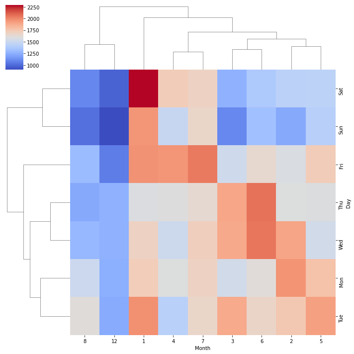

```python
sns.clustermap(dayandmonth, cmap='coolwarm')
```